# Measuring the Statistical Performance of Countries: An Overview of the SPI Index

SPI Team

2020-09-18

Abstract

Recognizing the new challenges for national statistical systems in monitoring the Sustainable Development Goals (SDGs), the World Bank is developing a new, improved Statistical Performance Indicators (SPI) to monitor progress of the statistical performance of countries. This will replace the Statistical Capacity Index (SCI) the World Bank has regularly published since 2004. This short note briefly discusses the motivation behind the new SPI, describes some of its major features, and discusses a new index based on the indicators.

# Motivation

The primary purpose of the statistical system is to help users of statistics make better decisions or to hold those decision makers accountable. In the words of Principle 1 of the Fundamental Principles of Official Statistics, the statistics must “meet the test of practical utility”, serving “the Government, the economy and the public with data about the economic, demographic, social and environmental situation.” The national statistical system, or NSS, plays a crucial role in modern economies. It provides stakeholders, ranging from policy makers to stock market analysts and the general public, with the latest data on the country’s socio-economic developments. At the international level, monitoring progress on global undertakings such as the recently established Sustainable Development Goals (SDGs) requires high-quality data that must be produced consistently across different national statistical systems. Assessing and improving the capacity of a country’s NSS has long been a part of the global agenda. Since the early 2000s, a few capacity assessment tools have been developed to identify the weaknesses and strengths of national statistical systems by other organizations including PARIS21, the Food and Agriculture Organization of the United Nations (FAO), the United Nations Economic Commission for Europe (UNECE), the United Nations Economic Commission for Africa (UNECA), and the U.S. Census Bureau.

Yet, there are several areas in which the existing SCI can be improved. First, it comprises of a limited number of indicators and includes no indicators of some important data sources, such as labor force surveys, establishment surveys, or administrative data. Second, it ignores the data dissemination practices of an NSS, which is one of the key features of data usage. Third, the SCI has been criticized for placing too much weight on statistical output and activities, while neglecting the infrastructure and resource components of statistical systems. Finally, it is silent on whether the data products produced by the NSS are in high demand. Since its launch in 2004, the SCI’s methodology and coverage have basically remained the same, while the global data landscape has changed significantly. NSSs have made significant advancements with data collection and dissemination practices. At the same time, the adoption of the Sustainable Development Goals (SDGs) set an ambitious development agenda for the next 15 years on ending poverty, protecting the planet, and ensuring prosperity for all by 2030. This, in turn, increased the demand for data and raised the bar for national statistical systems regarding their capacity to produce high-quality data. We thus propose to improve the current SCI to better suit the changing global data landscape.

# Overview of the New SPI

The new Statistical Performance Indicators (SPI) builds on the SCI, which the World Bank has regularly published since 2004. Our new SPI will cover many of the same elements as the SCI, such as statistical methodology, source data, and periodicity, but will also expand into new areas. The goals are to offer a framework that was forward looking, measured less mature statistical systems as well as advanced systems, covered the entire national statistical system, not just the National Statistical Office (NSO), and gives countries incentives to build a modern statistical system. We also are committing to making our project open data and open code to build confidence in our work.

The new Statistical Performance Indicators (SPI) are designed to monitor how well countries statistical systems are meeting this purpose. By helping countries and development partners identify the strengths and weaknesses of national statistical systems the SPI can support policy advice for countries about their national statistical systems, investment decisions for donors including the World Bank, benchmarking of national statistical systems, and advocacy for national statistics.

We identify five key drivers of a country’s statistical performance. These are data use, data services, data products, data sources, and data infrastructure.

Statistics have no value unless they are used. The first dimension of the Dashboard is therefore data use. A successful statistical system is one that produces data products that are highly used.

In order to meet those needs, the statistical system needs to develop a range of services that connect users and suppliers and facilitate dialogue between them. The second dimension of the SPI is therefore data services that are trusted by users. A successful statistical system is one with highly valued and well used statistical services.

The dialogue between users and suppliers in turn drives the design of statistical products that are to be created including the quality of product needed for the country requirement. This will incorporate accuracy, timeliness, frequency, comparability and levels of disaggregation. The third dimension of the SPI is therefore data products. A successful statistical system is one that generates high quality statistical indicators that can track progress for the Sustainable Development Goals (SDGs).

In order to create the products required, the statistical system needs to make use of a variety of sources from both inside and outside the government. This will include making use of typical data collection methods like censuses and surveys, but also administrative data, geospatial data, and data generated from the private sector and from citizens. The fourth dimension of the Dashboard is therefore data sources. A successful statistical system is one which draws on all types of data sources relevant to the indicators that are to be produced.

For the cycle to be complete, capability needs continuously to be reviewed to ensure that it is enough to deliver the products, services and ultimately data use required. The fifth dimension of the SPI is therefore data infrastructure. A successful statistical system is one that develops both hard infrastructure (legislation, governance, standards) and soft infrastructure (skills, partnerships) and has the financial resources to deliver. The 5 dimensions and associated 22 components of the SPI are as shown in Figure 1 below.

*Figure 1: The Dimensions and Components that Construct the New SPI*

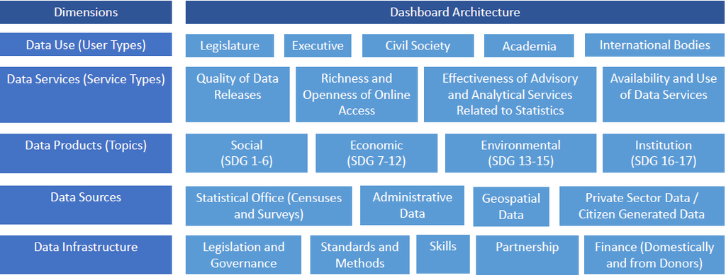

# Index Methodology

For research purposes, we create an index combining several indicators together to get an overview of country performance.

A quick primer on names. We refer to the 5 rows in the framework in Figure 1 as dimensions. We refer to the 22 cells in the framwork in Figure 1 as sub-dimensions. Finally, each sub-dimension may be composed of multiple indicators. For instance, the sub-dimension on censuses and surveys is made up indicators on whether population censuses have been conducted, agriculture censuses, labor force surveys, etc.

Below is the full set of indicators available to populate the index. along with the corresponding sub-dimension

| SPI Sub-Indicator Metadata. ID | SPI Sub-Indicator Metadata. Indicator Name | SPI Sub-Indicator Metadata. Sub-Dimension | SPI Sub-Indicator Metadata. Brief Description |
| --- | --- | --- | --- |
| SPI.D1.5.POV | Availability of Comparable Poverty headcount ratio at $1.90 a day (5 year moving average) | Indicator 1.5 | Comparability data from World Bank's Povcalnet |
| SPI.D1.5.CHLD.MORT | Availability of Mortality rate, under-5 (per 1,000 live births) data meeting quality standards according to UN IGME (5 year moving average) | Indicator 1.5 | Child Mortality Metadata from UN IGME |
| SPI.D1.5.DT.TDS.DPPF.XP.ZS | Quality of Debt service data according to World Bank | Indicator 1.5 | Debt Reporting Metadata from World Bank |
| SPI.D2.1.GDDS | SDDS/e-GDDS subscription | Indicator 2.1 | IMF GDDS compliance indicator |
| SPI.D2.2.Machine.readable | ODIN Machine Readability Score | Indicator 2.2 | ODW Open Data Index score |
| SPI.D2.2.Non.proprietary | ODIN Non Proprietary Data Format score | Indicator 2.2 | ODW Open Data Index score |
| SPI.D2.2.Download.options | ODIN Download Options score | Indicator 2.2 | ODW Open Data Index score |
| SPI.D2.2.Metadata.available | ODIN Metadata Availability score | Indicator 2.2 | ODW Open Data Index score |
| SPI.D2.2.Terms.of.use | ODIN Terms of Use score | Indicator 2.2 | ODW Open Data Index score |
| SPI.D2.2.Openness.subscore | ODIN Open Data Openness score | Indicator 2.2 | ODW Open Data Index score |
| SPI.D2.3.DSAS | NSO Website | Indicator 2.3 | New indicator of number of non-recurring products on NSO website (ad hoc/experimental rather than regular releases). The indicator is the number of products found. |
| SPI.D2.4.NADA | NADA metadata | Indicator 2.4 | NADA/NSO websites |
| SPI.D3.1.POV | GOAL 1: No Poverty (5 year moving average) | Indicator 3.1 | Fraction of Indicators in Goal 1 with value produced by countries statistical system |
| SPI.D3.2.HNGR | GOAL 2: Zero Hunger (5 year moving average) | Indicator 3.2 | Fraction of Indicators in Goal 2 with value produced by countries statistical system |
| SPI.D3.3.HLTH | GOAL 3: Good Health and Well-being (5 year moving average) | Indicator 3.3 | Fraction of Indicators in Goal 3 with value produced by countries statistical system |
| SPI.D3.4.EDUC | GOAL 4: Quality Education (5 year moving average) | Indicator 3.4 | Fraction of Indicators in Goal 4 with value produced by countries statistical system |
| SPI.D3.5.GEND | GOAL 5: Gender Equality (5 year moving average) | Indicator 3.5 | Fraction of Indicators in Goal 5 with value produced by countries statistical system |
| SPI.D3.6.WTRS | GOAL 6: Clean Water and Sanitation (5 year moving average) | Indicator 3.6 | Fraction of Indicators in Goal 6 with value produced by countries statistical system |
| SPI.D3.7.ENRG | GOAL 7: Affordable and Clean Energy (5 year moving average) | Indicator 3.7 | Fraction of Indicators in Goal 7 with value produced by countries statistical system |
| SPI.D3.8.WORK | GOAL 8: Decent Work and Economic Growth (5 year moving average) | Indicator 3.8 | Fraction of Indicators in Goal 8 with value produced by countries statistical system |
| SPI.D3.9.INDY | GOAL 9: Industry, Innovation and Infrastructure (5 year moving average) | Indicator 3.9 | Fraction of Indicators in Goal 9 with value produced by countries statistical system |
| SPI.D3.10.NEQL | GOAL 10: Reduced Inequality (5 year moving average) | Indicator 3.10 | Fraction of Indicators in Goal 10 with value produced by countries statistical system |
| SPI.D3.11.CITY | GOAL 11: Sustainable Cities and Communities (5 year moving average) | Indicator 3.11 | Fraction of Indicators in Goal 11 with value produced by countries statistical system |
| SPI.D3.12.CNSP | GOAL 12: Responsible Consumption and Production (5 year moving average) | Indicator 3.12 | Fraction of Indicators in Goal 12 with value produced by countries statistical system |
| SPI.D3.13.CLMT | GOAL 13: Climate Action (5 year moving average) | Indicator 3.13 | Fraction of Indicators in Goal 13 with value produced by countries statistical system |
| SPI.D3.14.LFWT | GOAL 14: Life Below Water (5 year moving average) | Indicator 3.14 | Fraction of Indicators in Goal 14 with value produced by countries statistical system |
| SPI.D3.15.LAND | GOAL 15: Life on Land (5 year moving average) | Indicator 3.15 | Fraction of Indicators in Goal 15 with value produced by countries statistical system |
| SPI.D3.16.INST | GOAL 16: Peace and Justice Strong Institutions (5 year moving average) | Indicator 3.16 | Fraction of Indicators in Goal 16 with value produced by countries statistical system |
| SPI.D3.17.PTNS | GOAL 17: Partnerships to achieve the Goal (5 year moving average) | Indicator 3.17 | Fraction of Indicators in Goal 17 with value produced by countries statistical system |
| SPI.D4.1.1.POPU | Population & Housing census (Availability score over 20 years) | Indicator 4.1 | SPI scores for sources dimension |
| SPI.D4.1.2.AGRI | Agriculture census (Availability score over 20 years) | Indicator 4.1 | SPI scores for sources dimension |
| SPI.D4.1.3.BIZZ | Business/establishment census (Availability score over 20 years) | Indicator 4.1 | SPI scores for sources dimension |
| SPI.D4.1.4.HOUS | Household Survey on income, etc (Availability score over 10 years) | Indicator 4.1 | SPI scores for sources dimension |
| SPI.D4.1.5.AGSVY | Agriculture survey (Availability score over 10 years) | Indicator 4.1 | SPI scores for sources dimension |
| SPI.D4.1.6.LABR | Labor Force Survey (Availability score over 10 years) | Indicator 4.1 | SPI scores for sources dimension |
| SPI.D4.1.7.HLTH | Health/Demographic survey (Availability score over 10 years) | Indicator 4.1 | SPI scores for sources dimension |
| SPI.D4.1.8.BZSVY | Business/establishment survey (Availability score over 10 years) | Indicator 4.1 | SPI scores for sources dimension |
| SPI.D4.2.1.SPL | Social Protection Admin (ASPIRE) (5 year moving average) | Indicator 4.2 | indicator on quality of vital registration data plus score based on density of administrative data available on key World Bank, UNESCO and ILO databases |
| SPI.D4.2.2.EDU | Education (UNESCO) (5 year moving average) | Indicator 4.2 | indicator on quality of vital registration data plus score based on density of administrative data available on key World Bank, UNESCO and ILO databases |
| SPI.D4.2.3.CRVS | CRVS (WDI) | Indicator 4.2 | indicator on quality of vital registration data plus score based on density of administrative data available on key World Bank, UNESCO and ILO databases |
| SPI.D4.2.4.LBR | Labor Admin (ILO) (5 year moving average) | Indicator 4.2 | indicator on quality of vital registration data plus score based on density of administrative data available on key World Bank, UNESCO and ILO databases |
| SPI.D4.3.GEO.first.admin.level | Geospatial data available at 1st Admin Level | Indicator 4.3 | Open Data Watch |
| SPI.D4.3.GEO.second.admin.level | Geospatial data available at 2nd Admin Level | Indicator 4.3 | Open Data Watch |
| SPI.D4.4.SOPC | NSO Website | Indicator 4.4 | New indicator based on references to private/citizen generated data in metadata relating to content on NSO website |
| SPI.D5.1.DILG | Legislation Indicator based on PARIS21 indicators on SDG 17.18.2 | Indicator 5.1 | New indicator based on PARIS21 indicators on SDG 17.18.2 (national statistical legislation compliance with UN Fundamental Principles of Official Statistics), existence of National Statistical Council,… |
| SPI.D5.2.1.SNAU | System of national accounts in use | Indicator 5.2 | SPI scores for standards and methods dimension |
| SPI.D5.2.2.NABY | National Accounts base year | Indicator 5.2 | SPI scores for standards and methods dimension |
| SPI.D5.2.3.CNIN | Classification of national industry | Indicator 5.2 | SPI scores for standards and methods dimension |
| SPI.D5.2.4.CPIBY | CPI base year | Indicator 5.2 | SPI scores for standards and methods dimension |
| SPI.D5.2.5.HOUS | Classification of household consumption | Indicator 5.2 | SPI scores for standards and methods dimension |
| SPI.D5.2.6.EMPL | Classification of status of employment | Indicator 5.2 | SPI scores for standards and methods dimension |
| SPI.D5.2.7.CGOV | Central government accounting status | Indicator 5.2 | SPI scores for standards and methods dimension |
| SPI.D5.2.8.FINA | Compilation of government finance statistics | Indicator 5.2 | SPI scores for standards and methods dimension |
| SPI.D5.2.9.MONY | Compilation of monetary and financial statistics | Indicator 5.2 | SPI scores for standards and methods dimension |
| SPI.D5.2.10.GSBP | Business process | Indicator 5.2 | SPI scores for standards and methods dimension |
| SPI.D5.3.DISK | PARIS21 indicator on data literacy | Indicator 5.3 | New indicator drawing on PARIS21 indicators such as statistical society presence and data literacy. PARIS21 may also have material on Internal skills capacity and numbers of statistically qualified pe… |
| SPI.D5.4.DIPN | NSO Website | Indicator 5.4 | New indicator based on textual analysis of NSS reports/websites for references to partner organisations. |
| SPI.D5.5.DIFI | Finance Indicator based on PARIS21 indicators on SDG 17.18.3 & SDG 17.19.1 | Indicator 5.5 | Indicator based on PARIS21 SDG indicators (SDG 17.18.3 (national statistical plan that is fully funded and under implementation) and SDG 17.19.1 (value of resources made available to strengthen statis… |

The Index will contain only a subset of the sub-dimensions from our framework. For dimensions excluded, we either lacked a source with a developed methodology or else the data collection for that measure was incomplete. This is described below:

- **Indicator 1.1: Data use by national legislature:** *Not included because of lack of established methodology*
- **Indicator 1.2: Data use by national executive branch:** *Not included because of lack of established methodology*
- **Indicator 1.3: Data use by civil society:** *Not included because of lack of established methodology*
- **Indicator 1.4: Data use by academia:** *Not included because of lack of established methodology*
- **Indicator 1.5: Data use by international organizations:** *Not included because of lack of established methodology*
- **Indicator 2.1: Data Releases:** *SPI.D2.1.GDDS - SDDS/e-GDDS subscription*
- **Indicator 2.2: Online access:** *SPI.D2.2.Openness.subscore ODIN Open Data Openness score*
- **Indicator 2.3: Advisory/ Analytical Services:** *Not included because of lack of established methodology*
- **Indicator 2.4: Data services:** *SPI.D2.4.NADA NADA metadata*
- **Indicator 3.1: Social Statistics:** *Average score for Goal 1-6 indicators*
- **Indicator 3.2: Economic Statistics:** *Average score for Goal 7-12 indicators*
- **Indicator 3.3: Environmental Statistics:** *Average score for Goal 13-15 indicators*
- **Indicator 3.4: Institutional Statistics:** *Average score for Goal 16-17 indicators*
- **Indicator 4.1: Censuses and Surveys:** *Average score Census and Survey Indicators indicators SPI.D4.1….*
- **Indicator 4.2: Administrative Data:** *Average score for CRVS indicator and Education (UNESCO) admin data indicator. Social Protection and Labor admin data indicators not included because of lack of established methodolgy*
- **Indicator 4.3: Geospatial Data:** *SPI.D4.3.GEO.first.admin.level - Geospatial data available at 1st Admin Level*
- **Indicator 4.4: Private/citizen generated data:** *Not included because of lack of established methodology*
- **Indicator 5.1: legislation and governance:** *Not included because of insufficient country coverage*
- **Indicator 5.2: Standards and Methods:** *Average score for Standards and Methods indicators SPI.D5.2….*
- **Indicator 5.3: skills:** *Not included because of lack of established methodology*
- **Indicator 5.4: partnerships:** *Not included because of lack of established methodology*
- **Indicator 5.5: finance:** *Not included because of insufficient country coverage*

This process of eliminating some sub-dimensions due to lack of established methodology or country coverage results in 11 sub-dimensions. This includes 3 on data services, 4 on data products, 3 on data sources, and 1 on data infrastructure.

After calculating the scores for each sub-dimension. The SPI index is the average across the 11 sub-dimensions. The SPI index has a maximum score of 100 and a minimum of 0. A score of 100 would indicate that a country has every single element that we measure in place. A score of 0 indicates that none are in place. To be precise:

$$SPI.INDEX_{ct} = \sum_{i=1}^N \frac{SPI.SUB.DIM_{ict}}{N}$$

Where SPI.INDEX is the SPI overall index. SPI.SUB.DIM are the 11 SPI sub-dimensions listed above. In the notation, c is a country, t is the date, i is a sub-dimension.

## Handling Missing Data

For a full description of the methodology behind each specific sub-indicator, please consult the technical documentation. However, we did follow an approach of handling missing values and lining up data, which I will describe in general terms below. For indicators where we had a value for a previous year (say a value in 2018 but not 2019), we would fill in from the previous value. For instance, the open data watch indicators on geo-spatial data was only released in 2018, not 2019, so we filled in the value for 2019 with the value from 2018 as our best estimate of that indicator.

For indicators where we had no data for any years, we chose not to impute a value. In that case, the value for that indicator is null and the country will not have a value for any sub-dimensions or dimensions where that value is used.

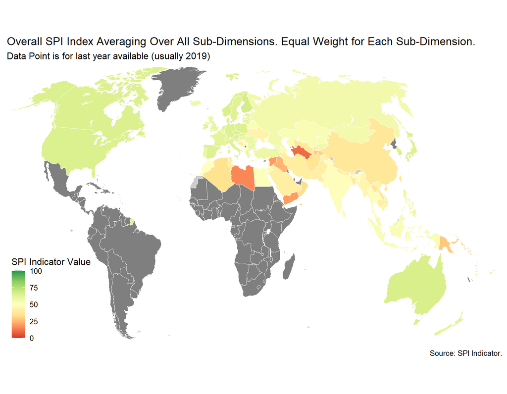

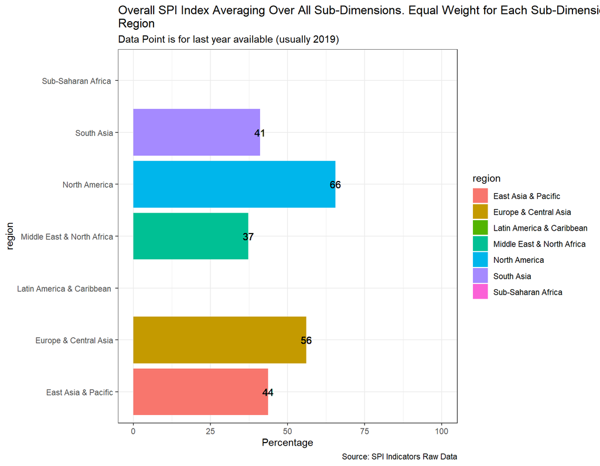

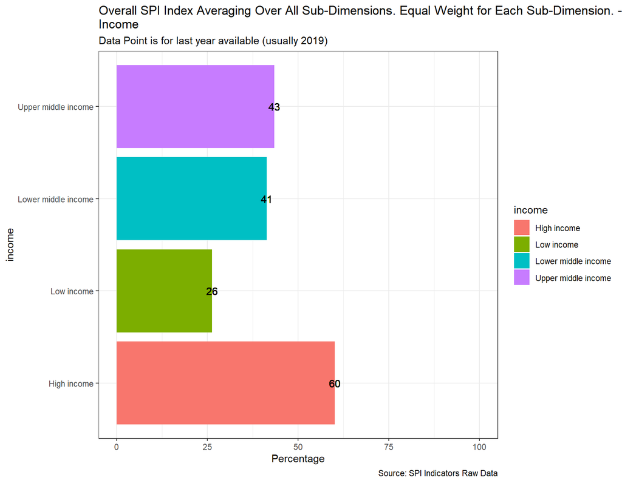

[figure not shown]

# Comparison to the Statistical Capacity Indicators

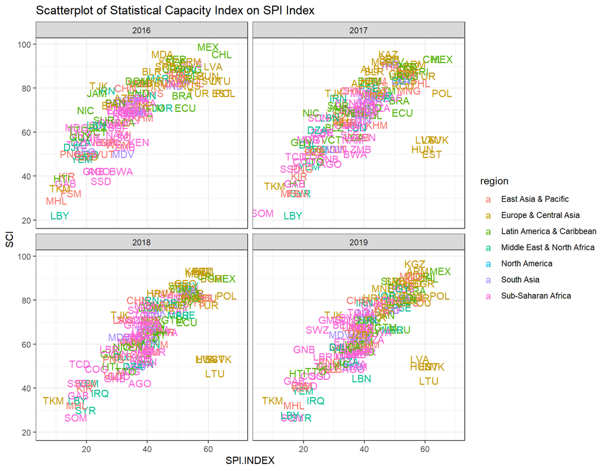

# ODIN ranking comparison

We compare the SPI index to the Open Data Watch rankings of country statistical systems (https://odin.opendatawatch.com/report/rankings). The correlation between the SPI index and the ODIN index is 0.8492594 `

# Annex